# Cách tính R0 ở trong 1 đại dịch

Tuấn Anh

# Sau đây chúng ta sẽ bắt đầu tìm hiểu về cách tính hệ số lây nhiễm cơ bản (Basic Reproduction Number) hay còn gọi là R0

# 1. Nhập những gói dữ kiện phân tích sau:

```r
library(earlyR)
library(incidence)
library(projections)
library(distcrete)
library(ggplot2)
```

**earlyR**: chịu trách nhiệm cho việc tính các thông số liên quan đến R0

**incidence** và **distcrete**: đóng vai trò gói dữ kiện bổ trợ cho phần tính toán số liệu của gói dữ kiện **earlyR**

**projections**: thiết lập các giá trị dự đoán về các nhiễm trong tương lai

**ggplot2**: gói dữ kiện giúp tạo ra biểu đồ rất đẹp

# 2. Nhập dữ liệu cần phân tích và tính các thông số cơ bản

```r
data = c(1,4,2,6,10,1,5,1,5,4,7,12,31,35,32,25,56)
```

```r
mean(data)
```

```
## [1] 13.94118
```

```r
sd(data)
```

```
## [1] 15.97839
```

# 3. Tính hệ số cơ bản

Tính **Hệ số cơ bản R0**

```r
R_estimate <- get_R(data, si_mean = 13.94, si_sd = 15.98)
R_estimate
```

```
##
## /// Early estimate of reproduction number (R) //
##  // class: earlyR, list
##
##  // Maximum-Likelihood estimate of R ($R_ml):
## [1] 4.764765
##
##
##  // $lambda:
##   NA 0.07854109 0.3827096 0.492354 0.9078232 1.589499...
##
##  // $dates:
## [1] 1 2 3 4 5 6
## ...
##
##  // $si (serial interval):
## A discrete distribution
##   name: gamma
##   parameters:
##     shape: 0.760977818017202
##     scale: 18.3185365853659
```

Tại đây, chúng ta nhận được kết quả **R0 = 4.764765 ~ 4.76** thông qua phương pháp tính Maximum-Likelihood

Sau đây là biểu đồ giá trị R0 đã ước tính từ đoạn code bên trên

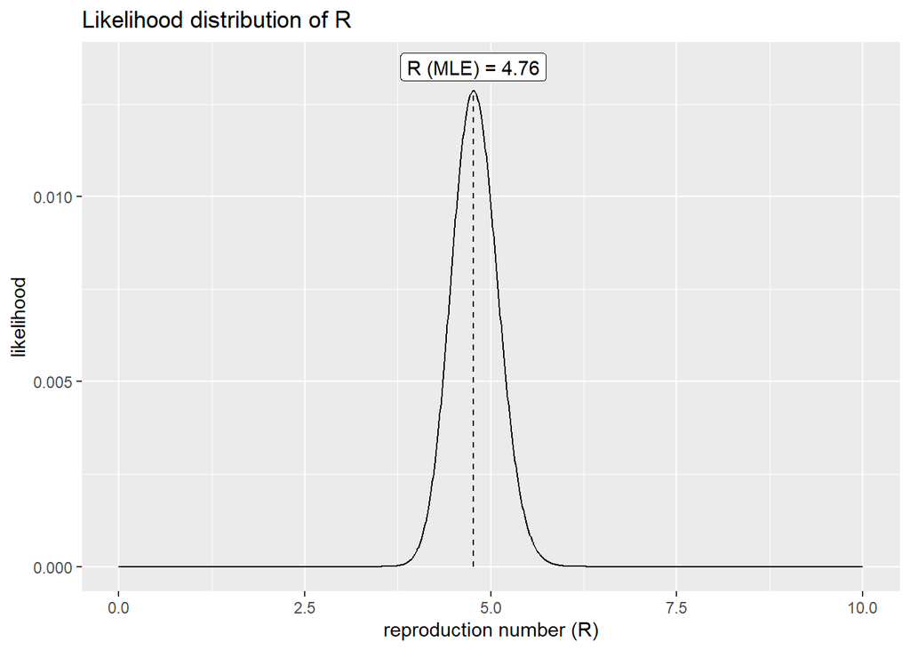

```r
plot(R_estimate)
```

Chúng ta tiếp tục thực hiện phép tính trên 1000 lần nữa và dựng biểu đồ tần suất dạng cột Histogram nhằm kiểm tra mức độ phân bố giá trị R0 sau 1000 lần được tính như thế nào

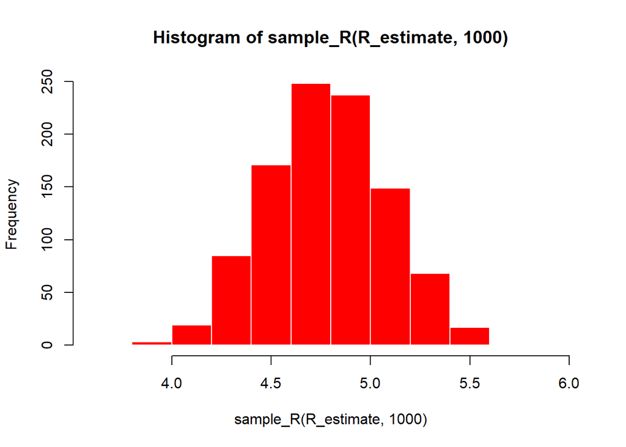

```r
hist(sample_R(R_estimate, 1000), col = "red", border = "white")
```

Như đã thấy trên biểu đồ, trong 1000 giá trị R0 tính toán, phần lớn trong số này rơi vào khoảng 4.5-5.0

Giờ chúng ta tiếp tục tính khoảng giá trị tin cậy (Confident Interval) 95% của hệ số R0 với số lần tính toán lặp lại 1000 lần

```r
quantile(sample_R(R_estimate, 1000), c(0.025, 0.975))
```

```
##     2.5%    97.5%
## 4.164164 5.415666
```

# 4. Chúng ta tiếp tục tính các dữ liệu dựa trên mô hình dự đoán

Tính các giá trị cần thiết

```r
R.inci <- incidence(c(1,2,3,4,5,6,7,8,9,10,11,12,13,14,15,16,17))
R.inci
```

```
## <incidence object>
## [17 cases from days 1 to 17]
##
## $counts: matrix with 17 rows and 1 columns
## $n: 17 cases in total
## $dates: 17 dates marking the left-side of bins
## $interval: 1 day
## $timespan: 17 days
## $cumulative: FALSE
```

```r
set.seed(1)
R.si <- distcrete("gamma", shape = 0.760977818017202,
                       scale = 18.3185365853659,
                       interval  = 1,
                       w = 0.5)
```

# 5. Dự đoán các ca nhiễm theo ngày trong 14 ngày tiếp theo

```r
pred_R_estimate <- project(R.inci, R = 4.764765, si = R.si, n_days = 14,
                          n_sim = 1000)
pred_R_estimate
```

```
##
## /// Incidence projections //
##
##   // class: projections, matrix, array
##   // 14 dates (rows); 1,000 simulations (columns)
##
##  // first rows/columns:
##    [,1] [,2] [,3] [,4] [,5] [,6]
## 18    3    3    5    5    1    3
## 19    7    7    2    5    3    7
## 20    6    8    2    6    1    7
## 21   15   12    8   13    6    8
##  .
##  .
##  .
##
##  // dates:
##  [1] 18 19 20 21 22 23 24 25 26 27 28 29 30 31
```

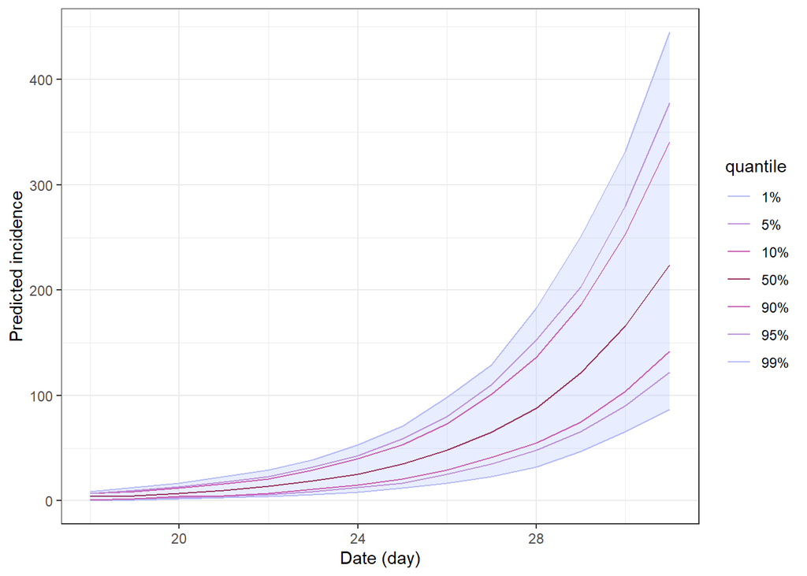

```r
plot(pred_R_estimate) + xlab("Date (day)") + theme_bw()
```

Biểu thị số ca nhiễm mỗi ngày cùng mức độ tin cậy 95%

```r
summary(pred_R_estimate, min = FALSE, max = FALSE, sd =FALSE, quantiles = c(0.025,0.975))
```

| dates | mean | quantiles.2.5% | quantiles.97.5% |
| --- | --- | --- | --- |
| 18 | 3.917 | 1.000 | 8.025 |
| 19 | 5.567 | 1.000 | 12.000 |
| 20 | 7.642 | 2.000 | 15.025 |
| 21 | 10.383 | 3.000 | 20.000 |
| 22 | 14.118 | 5.000 | 26.000 |
| 23 | 19.383 | 7.000 | 36.000 |
| 24 | 26.655 | 10.975 | 47.025 |
| 25 | 36.147 | 15.000 | 66.000 |
| 26 | 49.684 | 21.000 | 89.000 |
| 27 | 67.967 | 29.000 | 121.000 |

[output cut: 4 more lines]

# 6. Dự đoán các ca nhiễm cộng dồn theo ngày trong 14 ngày tiếp theo

```r
pred_R_cumulate <- cumulate(pred_R_estimate)
pred_R_cumulate
```

```
##
## /// Incidence projections //
##
##   // class: projections, matrix, array
##   // 14 dates (rows); 1,000 simulations (columns)
##
##  // first rows/columns:
##    [,1] [,2] [,3] [,4] [,5] [,6]
## 18    3    3    5    5    1    3
## 19   10   10    7   10    4   10
## 20   16   18    9   16    5   17
## 21   31   30   17   29   11   25
##  .
##  .
##  .
##
##  // dates:
##  [1] 18 19 20 21 22 23 24 25 26 27 28 29 30 31
##
##  // cumulative projections
```

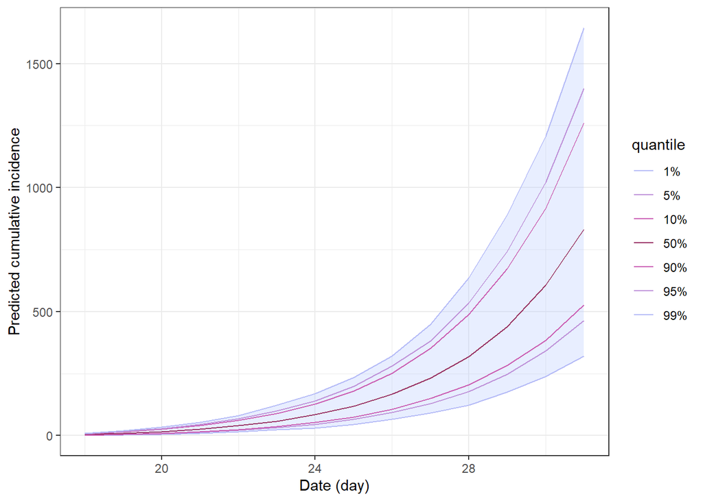

```r
plot(pred_R_cumulate) + xlab("Date (day)") + theme_bw()
```

```r
pred_R_estimate <- as.data.frame(pred_R_estimate, long = TRUE)
```

Biểu thị số ca nhiễm cộng dồn mỗi ngày cùng mức độ tin cậy 95% trong 14 ngày tiếp theo

```r
summary(pred_R_cumulate,min = FALSE, max = FALSE, sd =FALSE, quantiles = c(0.025,0.975))
```

| dates | mean | quantiles.2.5% | quantiles.97.5% |
| --- | --- | --- | --- |
| 18 | 3.917 | 1.000 | 8.025 |
| 19 | 9.484 | 3.000 | 18.000 |
| 20 | 17.126 | 6.000 | 31.025 |
| 21 | 27.509 | 11.000 | 49.000 |
| 22 | 41.627 | 18.000 | 72.025 |
| 23 | 61.010 | 27.975 | 106.025 |
| 24 | 87.665 | 40.000 | 151.025 |
| 25 | 123.812 | 56.950 | 214.025 |
| 26 | 173.496 | 78.000 | 300.075 |
| 27 | 241.463 | 109.975 | 421.075 |

[output cut: 4 more lines]

Từ các cách tính trên, chúng ta đã có thể tính được hệ số lây nhiễm cơ bản R0, dự đoán được số ca nhiễm hàng ngày và số ca nhiễm cộng dồn trong 14 ngày tiếp theo.

Hi vọng mọi người đã có cái nhìn tổng thể khi tính toán các số liệu liên quan đến dịch tễ

Các bài nghiên cứu đã áp dụng các gói dữ liệu trên để phân tích số liệu liên quan đến Covid-19 như [Tính hệ số lây nhiễm R0 trên con tàu Diamond Princess](https://pubmed.ncbi.nlm.nih.gov/32097725/)

Nếu có bất kỳ thắc mắc nào, vui lòng liên lạc qua Zalo **0867.507.572** hoặc **Email: mntanh.vet@gmail.com**